# Homework 4

Yanyu Chen

Assigned: 11/10/2021

### This homework is due before next class. To complete this assignment, follow these steps:

1. Download the `homework4.Rmd` file from Canvas or the course website.
2. Open `homework4.Rmd` in RStudio.
3. Replace the “Your Name Here” text in the `author:` field with your own name.
4. Supply your solutions to the homework by editing `homework4.Rmd`.
5. When you have completed the homework and have **checked** that your code both runs in the Console and knits correctly when you click `Knit HTML`, save the file as `HW4_yourandrewid.html`, and submit it on Canvas

### Loading packages

The code chunk below appears in the Rmd file, but won’t be displayed in your html output.

### Problem 1: A few simple plots

For this problem we’ll use the `diamonds` dataset from the `ggplot2` package.

##### (a) Base R graphics

Use the `hist` function to create a histogram of `carat` with bars colored `steelblue`.

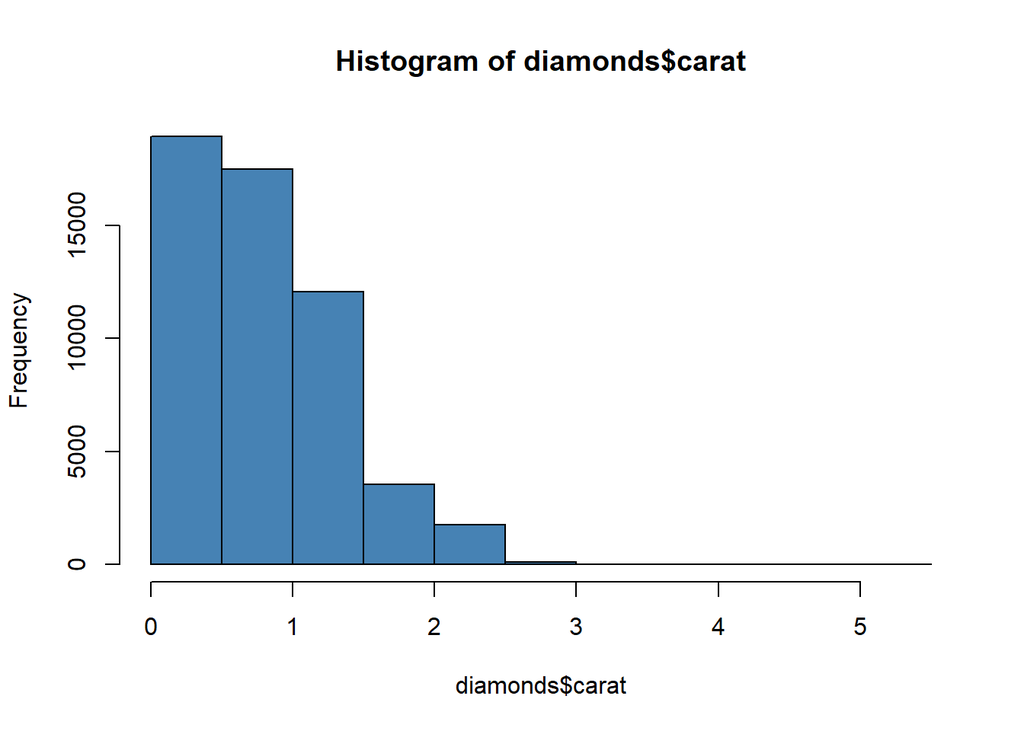

```r
diamond_hist_carat <- hist(diamonds$carat, col = 'steelblue')
```

##### (b) qplot histogram

Use the `qplot` function from the `ggplot2` package to create a histogram of `depth`. Note that `geom = "histogram"` is a valid geometry in `qplot`.

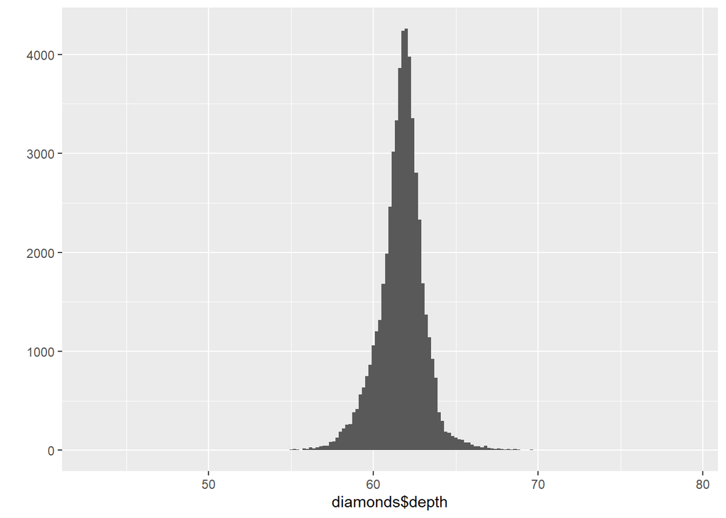

```r
diamond_hist_depth <- qplot(diamonds$depth, binwidth=0.2, geom='histogram')
diamond_hist_depth
```

##### (c) qplot violin plots

Use the `qplot` function from the `ggplot2` library to create violin plots showing how `price` varies across diamond `cut`. Specify `fill = cut` to get all the boxplots to be colored differently.

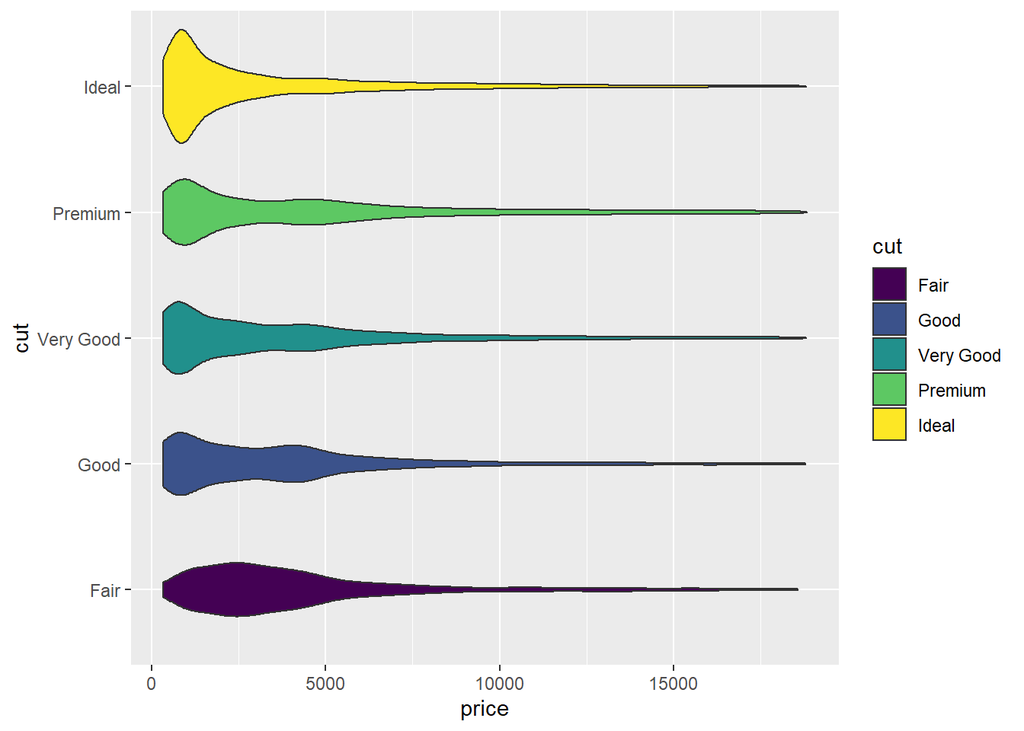

```r
diamond_violin_price <- qplot(price, cut, data=diamonds, fill=cut, geom='violin')
diamond_violin_price
```

**Hint**: For this exercise, it will be useful to know that `violin` is a geometry (`geom`) built into `ggplot2`, and that `qplot` can be called with the arguments:

```r
qplot(x, y, data, geom, fill)
```

### Problem 2: ggplot practice

For this exercise we’ll go back to the Cars93 data set in the MASS library

##### (a) size mapping, geom_point()

Define a `ggplot` object using the Cars93 data set that you can use to view `Price` on the y-axis, `MPG.highway` on the x-axis, and set the `size` mapping to be based on `Horsepower`.

Use `geom_point()` to create a scatterplot from your `ggplot` object.

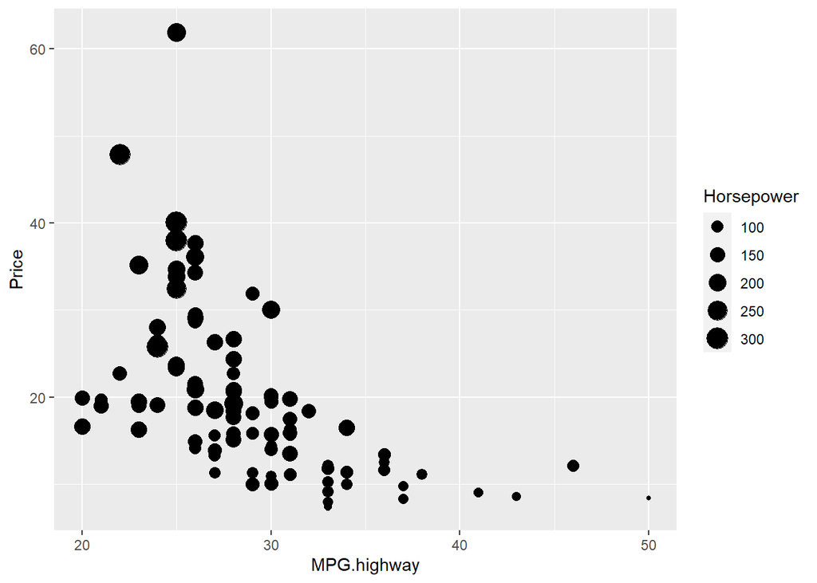

```r
cars93_scatter <- ggplot(data=Cars93, aes(MPG.highway, Price, size=Horsepower)) + geom_point()
cars93_scatter
```

##### (b) color mapping

Repeat part (a), this time also setting the `color` mapping to be based on `Origin`.

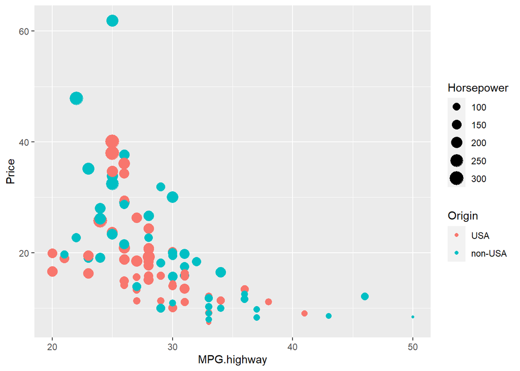

```r
cars93_scatter_2b <- ggplot(data=Cars93, aes(MPG.highway, Price, size=Horsepower, color=Origin)) + geom_point()
cars93_scatter_2b
```

##### (c) changing color palette

Repeat part (b), this time using the `scale_color_manual()` layer to specify that you want to use `cbPalette` as your color palette.

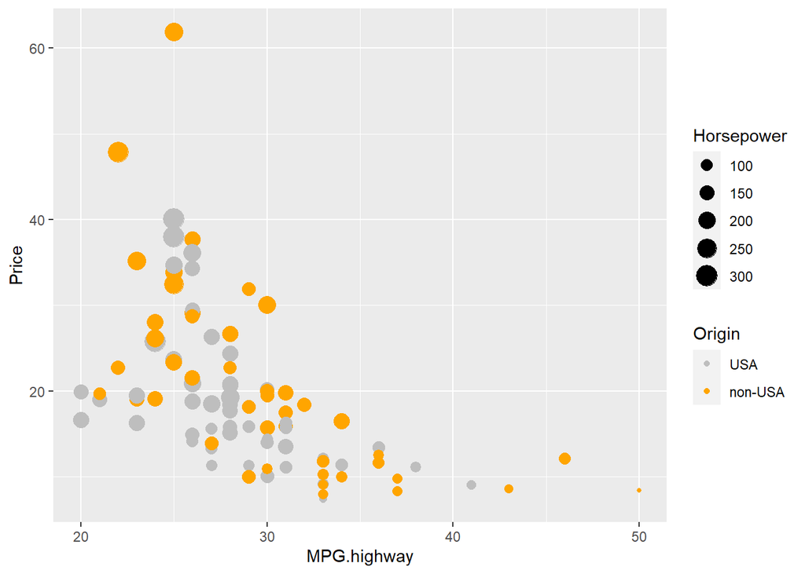

```r
cbPalette <- c("gray", "orange")
cars93_scatter_2c <- ggplot(data=Cars93, aes(MPG.highway, Price, size=Horsepower, color=Origin)) + geom_point() + scale_color_manual(values=cbPalette)
cars93_scatter_2c
```

### Problem 3: More ggplot2 practice

#####(a) stat_smooth()

Repeat part 2(b), this time using `stat_smooth()` to add a layer showing the smoothed curve representing how `Price` varies with `MPG.highway`.

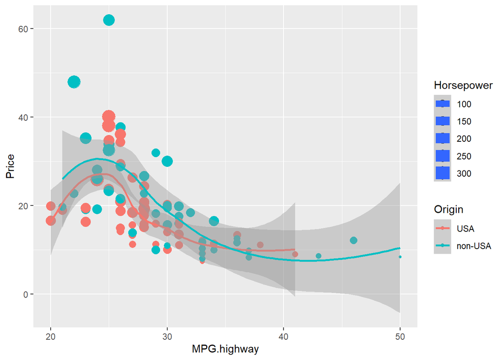

```r
cars93_scatter_3a <- ggplot(data=Cars93, aes(MPG.highway, Price, size=Horsepower, color=Origin)) + geom_point() + stat_smooth()
cars93_scatter_3a
```

#####(b) facet_grid()

Use your ggplot object from 2(b) along with the `geom_point()` and `facet_grid` layers to create scatterplots of `Price` against `MPG.highway`, broken down by (conditioned on) `Origin`.

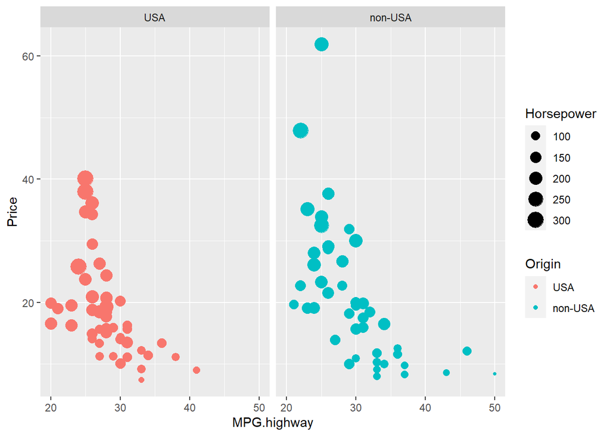

```r
cars93_scatter_3b <- ggplot(data=Cars93, aes(MPG.highway, Price, size=Horsepower, color=Origin)) + geom_point() + facet_grid(~Origin)
cars93_scatter_3b
```

(Your code should produce a figure with two scatterplots, analogous to the `facet_wrap` example from class.)

#####(c) Overlaying regression lines.

Modify your solution to part (b) to also display regression lines for each scatterplot.

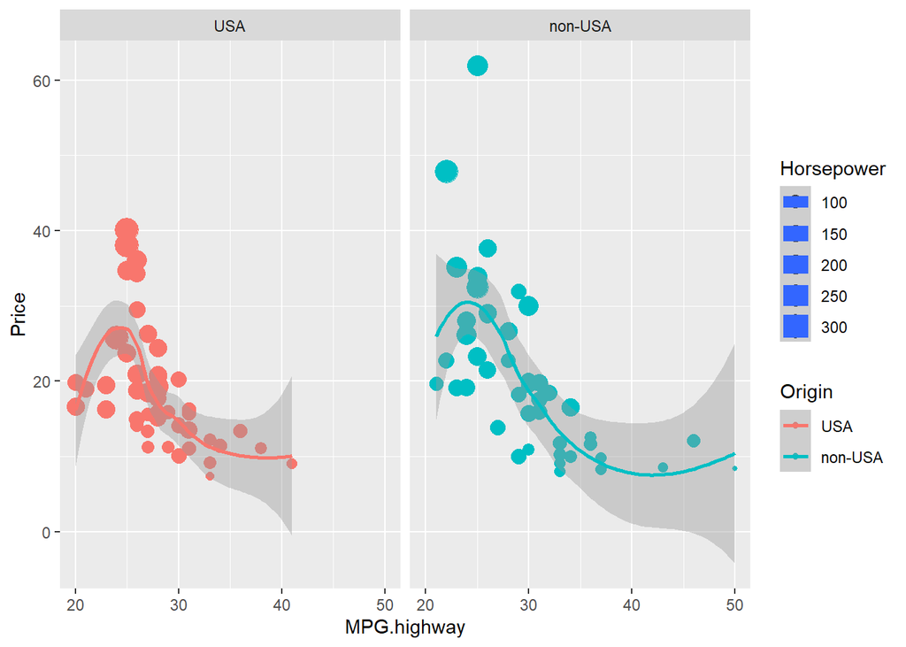

```r
cars93_scatter_3c <- ggplot(data=Cars93, aes(MPG.highway, Price, size=Horsepower, color=Origin)) + geom_point() + facet_grid(~Origin) + stat_smooth()
cars93_scatter_3c
```

### Problem 4: ddply() practice

This problem uses the Adult dataset, which we load below. The main variable of interest here is `high.income`, which indicates whether the individual’s income was over $50K. Anyone for whom `high.income == 1` is considered a “high earner”.

```r
adult.data <- read.csv("http://archive.ics.uci.edu/ml/machine-learning-databases/adult/adult.data", header=FALSE, fill=FALSE, strip.white=T,
                 col.names=c("age", "type_employer", "fnlwgt", "education",
                "education_num","marital", "occupation", "relationship", "race","sex",
                "capital_gain", "capital_loss", "hr_per_week","country", "income"))
adult.data <- mutate(adult.data,
                     high.income = as.numeric(income == ">50K"))
```

##### (a) Income by education level

Use the `ddply()` function to produce a summary table showing how many individuals there are in each `education_num` bin, and how the proportion of high earners varies across `education_num` levels. Your table should have column names: `education_num`, `count` and `high.earn.rate`.

```r
table_high.earn <- ddply(adult.data, .(education_num), summarise,
      count = length(education_num),
      high.earn.rate = sum(high.income == 1) / length(education_num))
table_high.earn
```

```
##    education_num count high.earn.rate
## 1              1    51     0.00000000
## 2              2   168     0.03571429
## 3              3   333     0.04804805
## 4              4   646     0.06191950
## 5              5   514     0.05252918
## 6              6   933     0.06645230
## 7              7  1175     0.05106383
## 8              8   433     0.07621247
## 9              9 10501     0.15950862
## 10            10  7291     0.19023454
## 11            11  1382     0.26121563
## 12            12  1067     0.24835989
## 13            13  5355     0.41475257
## 14            14  1723     0.55658735
## 15            15   576     0.73437500
## 16            16   413     0.74092010
```

##### (b) Constructing a bar chart

Using the `ggplot` and `geom_bar` commands along with your data summary from part **(a)** to create a bar chart showing the high earning rate on the y axis and `education_num` on the x axis. Specify that the color of the bars should be determined by the number of individuals in each bin.

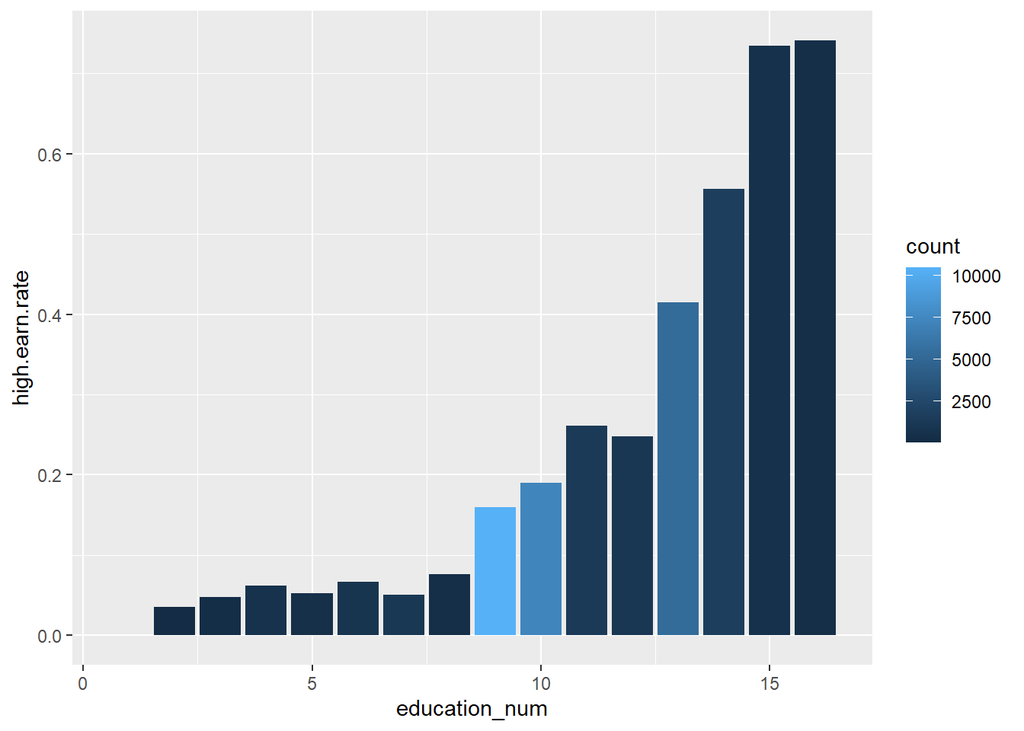

```r
plot_table_high.earn <- ggplot(data=table_high.earn, aes(x=education_num, y=high.earn.rate, fill=count)) + geom_histogram(stat='identity')
plot_table_high.earn
```

##### (c) summary table with multiple splitting variables

Use the `ddply()` function to produce a summary table showing how the proportion of high earners varies across all combinations of the following variables: `sex`, `race`, and `marital` (marital status). In addition to showing the proportion of high earners, your table should also show the number of individuals in each bin. Your table should have column names: `sex`, `race`, `marital`, `count` and `high.earn.rate`.

```r
table_high.earn2 <- ddply(adult.data, .(sex, race, marital), summarise,
      count = length(education_num),
      high.earn.rate = sum(high.income == 1) / length(education_num))
table_high.earn2
```

```
##       sex               race               marital count high.earn.rate
## 1  Female Amer-Indian-Eskimo              Divorced    36    0.055555556
## 2  Female Amer-Indian-Eskimo    Married-civ-spouse    21    0.380952381
## 3  Female Amer-Indian-Eskimo Married-spouse-absent     5    0.000000000
## 4  Female Amer-Indian-Eskimo         Never-married    39    0.051282051
## 5  Female Amer-Indian-Eskimo             Separated     8    0.000000000
## 6  Female Amer-Indian-Eskimo               Widowed    10    0.000000000
## 7  Female Asian-Pac-Islander              Divorced    51    0.078431373
## 8  Female Asian-Pac-Islander    Married-civ-spouse    83    0.349397590
## 9  Female Asian-Pac-Islander Married-spouse-absent    21    0.047619048
## 10 Female Asian-Pac-Islander         Never-married   161    0.037267081
## 11 Female Asian-Pac-Islander             Separated    10    0.100000000
## 12 Female Asian-Pac-Islander               Widowed    20    0.100000000
## 13 Female              Black              Divorced   342    0.064327485
## 14 Female              Black     Married-AF-spouse     1    1.000000000
```

[output cut: 49 more lines]

##### (d) Nicer table output using `kable()`

Use the `kable()` function from the `knitr` library to display the table from part **(c)** in nice formatting. You should use the `digits` argument to ensure that the values in your table are being rounded to a reasonable number of decimal places.

```r
kable_high.earn <- kable(table_high.earn2, format='html', digits=2)
kable_high.earn
```

| sex | race | marital | count | high.earn.rate |
| --- | --- | --- | --- | --- |
| Female | Amer-Indian-Eskimo | Divorced | 36 | 0.06 |
| Female | Amer-Indian-Eskimo | Married-civ-spouse | 21 | 0.38 |
| Female | Amer-Indian-Eskimo | Married-spouse-absent | 5 | 0.00 |
| Female | Amer-Indian-Eskimo | Never-married | 39 | 0.05 |
| Female | Amer-Indian-Eskimo | Separated | 8 | 0.00 |
| Female | Amer-Indian-Eskimo | Widowed | 10 | 0.00 |
| Female | Asian-Pac-Islander | Divorced | 51 | 0.08 |
| Female | Asian-Pac-Islander | Married-civ-spouse | 83 | 0.35 |
| Female | Asian-Pac-Islander | Married-spouse-absent | 21 | 0.05 |
| Female | Asian-Pac-Islander | Never-married | 161 | 0.04 |
| Female | Asian-Pac-Islander | Separated | 10 | 0.10 |
| Female | Asian-Pac-Islander | Widowed | 20 | 0.10 |
| Female | Black | Divorced | 342 | 0.06 |
| Female | Black | Married-AF-spouse | 1 | 1.00 |
| Female | Black | Married-civ-spouse | 159 | 0.32 |
| Female | Black | Married-spouse-absent | 41 | 0.02 |
| Female | Black | Never-married | 723 | 0.02 |
| Female | Black | Separated | 179 | 0.02 |
| Female | Black | Widowed | 110 | 0.01 |
| Female | Other | Divorced | 17 | 0.00 |
| Female | Other | Married-civ-spouse | 20 | 0.25 |
| Female | Other | Married-spouse-absent | 7 | 0.00 |
| Female | Other | Never-married | 51 | 0.02 |
| Female | Other | Separated | 9 | 0.00 |
| Female | Other | Widowed | 5 | 0.00 |
| Female | White | Divorced | 2226 | 0.07 |
| Female | White | Married-AF-spouse | 13 | 0.38 |
| Female | White | Married-civ-spouse | 1374 | 0.48 |
| Female | White | Married-spouse-absent | 131 | 0.07 |
| Female | White | Never-married | 3793 | 0.04 |
| Female | White | Separated | 425 | 0.03 |
| Female | White | Widowed | 680 | 0.06 |
| Male | Amer-Indian-Eskimo | Divorced | 24 | 0.17 |
| Male | Amer-Indian-Eskimo | Married-civ-spouse | 95 | 0.18 |
| Male | Amer-Indian-Eskimo | Married-spouse-absent | 4 | 0.00 |
| Male | Amer-Indian-Eskimo | Never-married | 64 | 0.05 |
| Male | Amer-Indian-Eskimo | Separated | 3 | 0.00 |
| Male | Amer-Indian-Eskimo | Widowed | 2 | 0.00 |
| Male | Asian-Pac-Islander | Divorced | 24 | 0.21 |
| Male | Asian-Pac-Islander | Married-civ-spouse | 425 | 0.48 |
| Male | Asian-Pac-Islander | Married-spouse-absent | 20 | 0.15 |
| Male | Asian-Pac-Islander | Never-married | 211 | 0.07 |
| Male | Asian-Pac-Islander | Separated | 9 | 0.33 |
| Male | Asian-Pac-Islander | Widowed | 4 | 0.25 |
| Male | Black | Divorced | 143 | 0.12 |
| Male | Black | Married-civ-spouse | 678 | 0.37 |
| Male | Black | Married-spouse-absent | 21 | 0.05 |
| Male | Black | Never-married | 623 | 0.04 |
| Male | Black | Separated | 86 | 0.02 |
| Male | Black | Widowed | 18 | 0.00 |
| Male | Other | Divorced | 9 | 0.11 |
| Male | Other | Married-civ-spouse | 85 | 0.20 |
| Male | Other | Married-spouse-absent | 8 | 0.00 |
| Male | Other | Never-married | 54 | 0.02 |
| Male | Other | Separated | 4 | 0.00 |
| Male | Other | Widowed | 2 | 0.00 |
| Male | White | Divorced | 1571 | 0.16 |
| Male | White | Married-AF-spouse | 9 | 0.44 |
| Male | White | Married-civ-spouse | 12036 | 0.45 |
| Male | White | Married-spouse-absent | 160 | 0.12 |
| Male | White | Never-married | 4964 | 0.06 |
| Male | White | Separated | 292 | 0.15 |
| Male | White | Widowed | 142 | 0.27 |

### Problem 5: Getting the right plot

##### (a) A more complex bar chart.

Using the table you created in 4(c), use ggplot graphics to construct a plot that looks like [the one at this link](http://www.andrew.cmu.edu/user/achoulde/94842/homework/target_fig.png)

**Hint** You may find it useful to use the following layers: `facet_grid`, `coord_flip` (for horizontal bar charts), `theme` (rotating x axis text) and `guides` (removing fill legend).

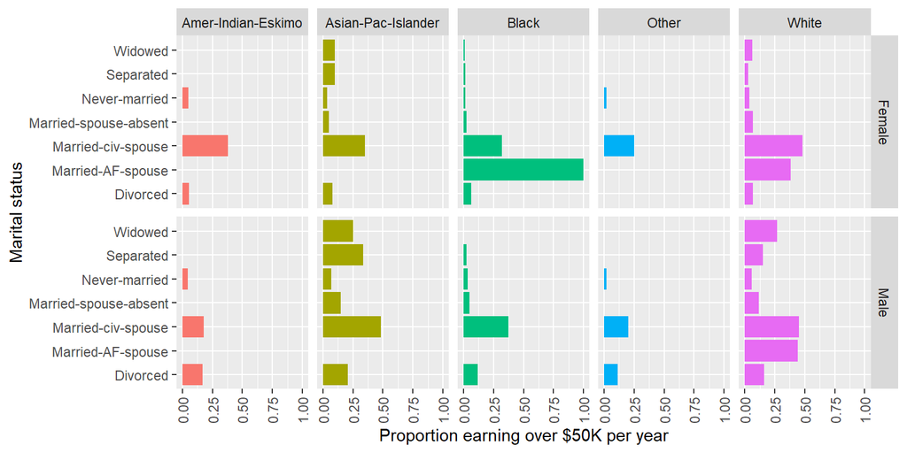

```r
plot_multi1 <- ggplot(data=table_high.earn2, aes(high.earn.rate, marital, fill=race)) + geom_histogram(stat= 'identity') + facet_grid(sex~race) + theme(axis.text.x = element_text(angle = 90, vjust = 0.5, hjust=1)) + guides(fill="none") + labs(x = "Proportion earning over $50K per year", y = "Marital status")
plot_multi1
```

##### (b) Hiding code with `echo`

Repeat part **(a)**, but this time set the `echo` argument of the code chunk in such a way that the code is not printed, but the plot is still displayed.

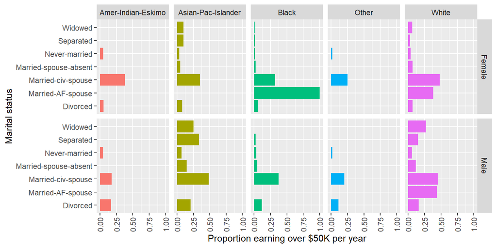

As usual, save your Rmd code, knit a complete html file and submit it on Canvas with a file name of `HW4_yourAndrewID.html`.